# Project Proposal - Data

Author

Adrian Tran, Harshitha Bachina, Hayden King, Josh Shneyder

## 1 Loading in the Data

```r
gdp = read.csv("~/Desktop/stat-331-71-PA6/gdppercapita_us_inflation_adjusted.csv")
life = read.csv("~/Desktop/stat-331-71-PA6/life_expectancy_years.csv")
```

## 2 Cleaning the Data

```r
library(tidyverse)
gdp_clean <- gdp |>
  pivot_longer(cols = "X1959":"X2019",
               names_to = "Year",
               values_to = "GDP")

life_clean <- life |>
  pivot_longer(cols = "X1959":"X2019",
               names_to = "Year",
               values_to = "Life_Expectancy") |>
  select("country", "Year", "Life_Expectancy")
```

We selected the years 1959-2019 because that’s when the GDP data is available.

### 2.1 Merging the Data

```r
joined_data = merge(gdp_clean, life_clean, by = c("Year", "country")) |>
  mutate(
    Year = str_remove(Year, "X"),
    thousand = 0,
    thousand = if_else(str_detect(GDP, "k"), 1, 0),
    GDP = as.double(str_remove(GDP, "k")),
    GDP = if_else(thousand == 1, GDP * 1000, GDP),
    lGDP = log(GDP)
  ) |>
  drop_na()
```

This code cleans the Year and GDP columns. It also creates a new column that has the natural log of GDP. We can use this to test if the relationship is linear or logarithmic.

```r
joined_data |>
  select(country) |>
  distinct() |>
  nrow()
```

```
[1] 192
```

We thought about categorizing the countries by continent or region, but we have 192 countries. That would take too long.

## 3 Hypothesized Relationship

We hypothesize that the relationship between GDP per capita and life expectancy will be logarithmic. As GDP increases, so does life expectancy, but with diminishing returns. Ln(GDP) and life expectancy should have a linear relationship. The relationship is likely stable over time.

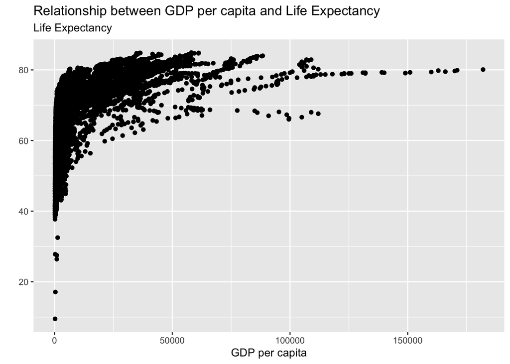

```r
library(ggplot2)
ggplot(data=joined_data, aes(x=GDP, y=Life_Expectancy)) +
  geom_point() +
  labs(x="GDP per capita", y="", subtitle = "Life Expectancy", title = "Relationship between GDP per capita and Life Expectancy")
```

The graph of GDP per capita and life expectancy shows a logarithmic relationship.

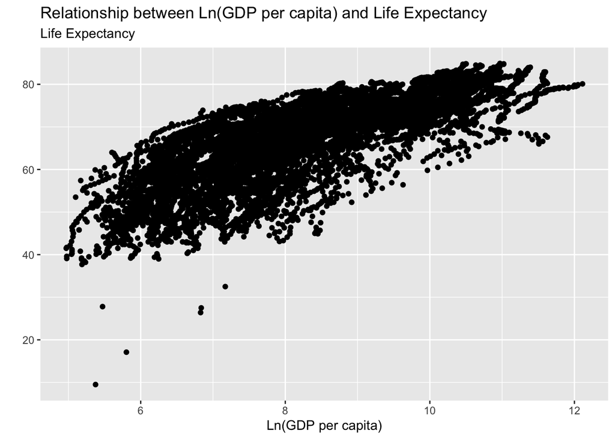

```r
ggplot(data=joined_data, aes(x=lGDP, y=Life_Expectancy)) +
  geom_point() +
  labs(x="Ln(GDP per capita)", y="", subtitle = "Life Expectancy", title = "Relationship between Ln(GDP per capita) and Life Expectancy")
```

By taking the natural log of the x axis (GDP per capita), the relationship is now linear.